# Case Law Analysis (CLA)

Project: Machine learning analysis of data extracted from criminal court documents

This project was published as: Machine learning analysis of a national sample of U.S. case law involving mental health evidence.

Please note that this notebook contains only a small example from the analyses performed for this project. The purpose of this notebook is to demonstrate the thought process and types of analyses performed and is not exhaustive or complete. The full analyses performed for each project are reported in the published article.

# Load libraries and data

```python
# Basic libraries
import pandas as pd
import numpy as np

import pingouin as pg
from bioinfokit.analys import stat
import scikit_posthocs as sp
import graphviz
from sklearn.tree import export_graphviz
import six
from six import StringIO
import pydotplus
import geopandas as gpd

# Libraries for graphs
import matplotlib.pyplot as plt
import matplotlib.gridspec as gridspec
from matplotlib import cm
from matplotlib.ticker import StrMethodFormatter
from matplotlib.ticker import FuncFormatter
import seaborn as sns
from matplotlib.colors import ListedColormap,LinearSegmentedColormap
from mpl_toolkits.axes_grid1 import make_axes_locatable
import networkx as nx
from IPython.display import Image

# Libraries for inferential stats
from pandas.api.types import CategoricalDtype
import patsy
from patsy import dmatrices

import scipy
from scipy import stats
from scipy.stats import shapiro
from scipy.stats import pearsonr

import sklearn
from sklearn.compose import ColumnTransformer
from sklearn.preprocessing import LabelEncoder, OneHotEncoder
from sklearn.model_selection import train_test_split, GridSearchCV
from sklearn.tree import DecisionTreeClassifier, plot_tree
from sklearn import metrics
from sklearn.metrics import confusion_matrix, classification_report
from sklearn.metrics import roc_curve, auc
from sklearn.preprocessing import label_binarize
from sklearn.pipeline import Pipeline
from sklearn.model_selection import cross_val_score, StratifiedKFold

## Deactivate warnings for this demo
import warnings
warnings.filterwarnings('ignore')
```

```python
# Load dataset as df

# Define path and load data
dfCLAmain = pd.read_csv("/Users/miat./Documents/OtherWork/Jobs-Grants/Portfolio/Jupyter/CLA-ML/CLA_ML.csv")
```

```python
# Print the first rows of the dataset
print(dfCLAmain.head(2))

# Check the shape of the dataset
dfCLAmain.shape
```

```
   Incl-Num                     DocTitle Jurisdiction AppealCourt  \
0         1  In re Brown Robert victim 2           MA         CoA
1         2               State v. Steed           TN        CoCA

  SentencingCourt  SentencingYear AffirmedORpartly AppealJudgeGender  \
0           CircC            1994              yes                 m
1           CrimC            2019              yes                 m

  AppealJudgeName SentencingJudgeGender  ... InstitutionalizationLength  \
0           GREEN                     f  ...                          0
1       WEDEMEYER                     m  ...                          0

  PostreleaseSupervision PostreleaseLength ProbationOnly  ProbationLength  \
0                     no                 0           yes               60
1                     no                 0           yes               72

   RehabOrTreatment  OtherSanction UltimatDeniedParole? Race  Notes
0                no      NoneKnown                   na    u    NaN
1                no      NoneKnown                   na    w    NaN

[2 rows x 50 columns]
```

```
(710, 50)
```

# Pre-processing and cleaning

```python
### Pre-processing

## Rename variables
dfCLAmain.rename(columns={'AffirmedORpartly': 'Affirmed'}, inplace=True)
dfCLAmain.rename(columns={'GuiltyPleaOrNoContest': 'GuiltyPlea'}, inplace=True)
dfCLAmain.rename(columns={'PostreleaseSupervision': 'PostreleaseSup'}, inplace=True)
dfCLAmain.rename(columns={'RehabOrTreatment': 'TreatmentOrder'}, inplace=True)

## Change category names
# Define a mapping of current categories to new categories
category_mapping1 = {'Behavioral ': 'Behavioral', 'Psychosis ': 'Psychosis'}
# Replace categories
dfCLAmain['Disorder1'] = dfCLAmain['Disorder1'].replace(category_mapping1)
dfCLAmain['Disorder2'] = dfCLAmain['Disorder2'].replace(category_mapping1)

# Define a mapping of current categories to new categories
category_mapping2 = {'no ': 'no'}
# Replace categories
dfCLAmain['TreatmentOrder'] = dfCLAmain['TreatmentOrder'].replace(category_mapping2)

# Define a mapping of current categories to new categories
category_mapping3 = {'m ': 'm'}
# Replace categories
dfCLAmain['Gender'] = dfCLAmain['Gender'].replace(category_mapping3)

# Define a mapping of current categories to new categories
category_mapping4 = {'no ': 'no'}
# Replace categories
dfCLAmain['DisorderRejectAggrav'] = dfCLAmain['DisorderRejectAggrav'].replace(category_mapping4)

# Define a mapping of current categories to new categories
category_mapping3 = {'ID ': 'ID'}
# Replace categories
dfCLAmain['Jurisdiction'] = dfCLAmain['Jurisdiction'].replace(category_mapping3)

# Define a mapping of current categories to new categories
category_mapping4 = {'b': 'Black',
                    'w': 'White',
                    'h': 'Hispanic',
                    'n': 'Native',
                    'o': 'Other',
                    'u': 'Unknown'}
# Replace categories
dfCLAmain['Race'] = dfCLAmain['Race'].replace(category_mapping4)
# Check
unique_categories = dfCLAmain['Disorder2'].unique()
print("Unique categories:", unique_categories)

# Convert categorical num variables to continuous numerical
dfCLAmain.loc[:, 'Disorder1severity':'DisorderTotalSeverity'] = dfCLAmain.loc[:, 'Disorder1severity':'DisorderTotalSeverity'].astype(int)
dfCLAmain['SentencingYear'] = dfCLAmain['SentencingYear'].astype(int)
# Check
print(dfCLAmain.dtypes['Disorder2severity'])
print(dfCLAmain.dtypes['SentencingYear'])

## Reorder
# Reorder variable
dfCLAmain['Race'] = pd.Categorical(dfCLAmain['Race'], ['White',
                                                       'Black',
                                                       'Hispanic',
                                                       'Native',
                                                       'Other',
                                                       'Unknown'])
# Check
unique_catsR = dfCLAmain['Race'].unique()
print(unique_catsR)
print(dfCLAmain.dtypes['Race'])

# Reorder variable
dfCLAmain['Affirmed'] = pd.Categorical(dfCLAmain['Affirmed'], ['yes',
                                                              'part',
                                                              'no'])

# Reorder variable
dfCLAmain['Age'] = pd.Categorical(dfCLAmain['Age'], ['0-18',
                                                    '18-40',
                                                    '40-60',
                                                    '60+'])


## Create new variable 'SentenceType'
# Create a new variable 'SentenceType' with default value 'Institution/Treat'
dfCLAmain['SentenceType'] = 'Institution/Treat'
# Update 'SentenceType' based on the conditions
dfCLAmain.loc[dfCLAmain['Imprisonment'] == 'yes', 'SentenceType'] = 'Imprisonment'
dfCLAmain.loc[dfCLAmain['Institutionalization'] == 'yes', 'SentenceType'] = 'Institution/Treat'
dfCLAmain.loc[dfCLAmain['ProbationOnly'] == 'yes', 'SentenceType'] = 'ProbationOnly'
# Check
unique_values = dfCLAmain['SentenceType'].unique()
print(unique_values)

## CriminalHistory has a few NaN
# Check unique values of the variable CriminalHistory
unique_criminal_history = dfCLAmain['CriminalHistory'].unique()
print("Unique values of CriminalHistory:", unique_criminal_history)
# Count the number of NaN values in the CriminalHistory column
num_nan_criminal_history = dfCLAmain['CriminalHistory'].isna().sum()
print("Number of NaN values in CriminalHistory:", num_nan_criminal_history)
# Replace NaN values with 'no' as we know missing value means no hisory found
dfCLAmain['CriminalHistory'].fillna('no', inplace=True)
# Check unique values of the variable CriminalHistory after replacing NaN values
unique_criminal_history = dfCLAmain['CriminalHistory'].unique()
print("Unique values of CriminalHistory after replacing NaN with 'no':", unique_criminal_history)

## Offenses
# Reorder variables (by seriousness)
dfCLAmain['Offense1'] = pd.Categorical(dfCLAmain['Offense1'], ['Murder capital',
            'Murder first-degree',
            'Rape aggravated',
            'Murder second-degree',
            'Rape vulnerable',
            'Sexual battery/Indecent assault aggravated',
            'Robbery armed',
            'Kidnapping first-degree/aggravated',
            'Sexual assault acts/first-degree',
            'Inchoate offense (murder)',
            'Violent sexual act attempt/second-degree vulnerable',
            'Sodomy first-degree',
            'Rape/Sexual assault attempt',
            'Kidnapping attempt',
            'Sex crimes non-violent vulnerable',
            'Assault armed',
            'Murder third-degree/attempt',
            'Assault aggravated/first-degree/felony',
            'Sexual assault second-degree',
            'Arson',
            'Abuse/Neglect aggravated vulnerable',
            'Death involving car',
            'Robbery',
            'Abuse/Neglect simple/attempt vulnerable',
            'Inchoate offense (assault/robbery)',
            'Robbery attempt',
            'Burglary armed/aggravated',
            'Using weapon',
            'Rape second-degree',
            'Burglary',
            'Deceive/mislead crimes',
            'Possession weapon',
            'Financial crimes',
            'Drug charges',
            'Assault law officer/protected professional',
            'Theft',
            'Battery/False imprisonment/Crim restraint',
            'Sexual offense third-degree',
            'Threats/Evesdropping/Illegal driving',
            'Assault/Battery aggravated/felony attempt',
            'Abuse corpse',
            'Riot, disorderly conduct, other',
            'Assault second-degree',
            'Animal cruelty aggravated',
            'Sexual offense fourth-degree',
            'Burglary third-degree',
            'Theft second-degree/attempt',
            'Assault/Other misd'])
```

```
Unique categories: [nan 'Addiction' 'MDnos' 'Mood' 'Behavioral' 'MDnosSEV' 'Intellectual'
 'Paraphilia' 'Trauma' 'Personality' 'Psychosis']
int64
int64
['Unknown', 'White', 'Black', 'Hispanic', 'Other', 'Native']
Categories (6, object): ['White', 'Black', 'Hispanic', 'Native', 'Other', 'Unknown']
category
['ProbationOnly' 'Imprisonment' 'Institution/Treat']
Unique values of CriminalHistory: ['yes' 'no' nan]
Number of NaN values in CriminalHistory: 8
Unique values of CriminalHistory after replacing NaN with 'no': ['yes' 'no']
```

```python
### Map states by geo location in 4 categories

# Get all states
unique_categories = dfCLAmain['Jurisdiction'].unique()
print("Unique categories:", unique_categories)

# List of states
states = ['MA', 'TN', 'IN', 'TX', 'IA', 'MD', 'MS', 'NY', 'OR', 'CT', 'KY', 'KS', 'VA', 'GA',
          'FL', 'MO', 'OH', 'ID', 'WY', 'CA', 'WV', 'PA', 'NE', 'AL', 'MI', 'AR', 'NV', 'NM',
          'MN', 'WA', 'NJ', 'NC', 'RI', 'HI', 'AZ', 'MT', 'SC', 'DE', 'IL', 'CO', 'SD', 'WI',
          'LA', 'VT', 'UT', 'ID']

# Dictionary mapping states to regions
region_mapping = {
    'South': ['TN', 'TX', 'MS', 'KY', 'VA', 'GA', 'FL', 'AL', 'AR', 'LA', 'SC', 'WV', 'NC'],
    'West': ['OR', 'ID', 'WY', 'CA', 'NV', 'WA', 'MT', 'HI', 'UT', 'CO', 'AZ', 'NM'],
    'Midwest': ['IN', 'IA', 'MO', 'OH', 'NE', 'MI', 'MN', 'WI', 'IL', 'SD', 'KS'],
    'Northeast': ['MA', 'MD', 'NY', 'CT', 'PA', 'NJ', 'RI', 'DE', 'VT']
}

# Function to assign region based on state
def get_region(state):
    for region, state_list in region_mapping.items():
        if state in state_list:
            return region
    return 'Unknown'

# Assign regions to states
state_regions = {state: get_region(state) for state in states}

# Sort states within each region
for region, state_list in region_mapping.items():
    region_mapping[region] = sorted(state_list)

# Add the 'region' variable to the main DataFrame
dfCLAmain['region'] = dfCLAmain['Jurisdiction'].map(state_regions)

# Check order
region_to_check = 'South'
if region_to_check in region_mapping:
    print(f"States in {region_to_check}: {region_mapping[region_to_check]}")
else:
    print(f"Region '{region_to_check}' not found.")

# Reorder variable
dfCLAmain['region'] = pd.Categorical(dfCLAmain['region'], ['South',
                                                       'West',
                                                       'Midwest',
                                                       'Northeast'])
```

```
Unique categories: ['MA' 'TN' 'IN' 'TX' 'IA' 'MD' 'MS' 'NY' 'OR' 'CT' 'KY' 'KS' 'VA' 'GA'
 'FL' 'MO' 'OH' 'ID' 'WY' 'CA' 'WV' 'PA' 'NE' 'AL' 'MI' 'AR' 'NV' 'NM'
 'MN' 'WA' 'NJ' 'NC' 'RI' 'HI' 'AZ' 'MT' 'SC' 'DE' 'IL' 'CO' 'SD' 'WI'
 'LA' 'VT' 'UT']
States in South: ['AL', 'AR', 'FL', 'GA', 'KY', 'LA', 'MS', 'NC', 'SC', 'TN', 'TX', 'VA', 'WV']
```

```python
### Map states by politics in 3 categories

# Get all states
unique_categories = dfCLAmain['Jurisdiction'].unique()
print("Unique categories:", unique_categories)

# List of states
states = ['MA', 'TN', 'IN', 'TX', 'IA', 'MD', 'MS', 'NY', 'OR', 'CT', 'KY', 'KS', 'VA', 'GA',
          'FL', 'MO', 'OH', 'ID', 'WY', 'CA', 'WV', 'PA', 'NE', 'AL', 'MI', 'AR', 'NV', 'NM',
          'MN', 'WA', 'NJ', 'NC', 'RI', 'HI', 'AZ', 'MT', 'SC', 'DE', 'IL', 'CO', 'SD', 'WI',
          'LA', 'VT', 'UT', 'ID']

# Dictionary mapping states to politics
politics_mapping = {
    'Red': ['MT', 'WY', 'ID', 'TN', 'TX', 'MS', 'KY', 'VA', 'GA', 'FL', 'AL', 'AR', 'LA', 'SC', 'WV', 'NC', 'SD', 'KS', 'MO', 'UT'],
    'Purple': ['NE', 'NV', 'CO', 'AZ', 'NM', 'WI', 'OH', 'MI', 'IN', 'IA'],
    'Blue': ['OR', 'WA', 'CA', 'MN', 'IL', 'MA', 'MD', 'NY', 'CT', 'PA', 'NJ', 'RI', 'DE', 'VT', 'HI']
}

# Function to assign politics based on state
def get_politics(state):
    for politics, state_list in politics_mapping.items():
        if state in state_list:
            return politics
    return 'Unknown'

# Assign politics to states
state_politics = {state: get_politics(state) for state in states}

# Sort states within each political leaning
for politics, state_list in politics_mapping.items():
    politics_mapping[politics] = sorted(state_list)

# Add the 'politics' variable to the main DataFrame
dfCLAmain['politics'] = dfCLAmain['Jurisdiction'].map(state_politics)

# Check order
politics_to_check = 'Red'
if politics_to_check in politics_mapping:
    print(f"States in {politics_to_check}: {politics_mapping[politics_to_check]}")
else:
    print(f"Politics '{politics_to_check}' not found.")

# Reorder the 3 categories
dfCLAmain['politics'] = pd.Categorical(dfCLAmain['politics'], ['Blue',
                                                              'Purple',
                                                              'Red'])
```

```
Unique categories: ['MA' 'TN' 'IN' 'TX' 'IA' 'MD' 'MS' 'NY' 'OR' 'CT' 'KY' 'KS' 'VA' 'GA'
 'FL' 'MO' 'OH' 'ID' 'WY' 'CA' 'WV' 'PA' 'NE' 'AL' 'MI' 'AR' 'NV' 'NM'
 'MN' 'WA' 'NJ' 'NC' 'RI' 'HI' 'AZ' 'MT' 'SC' 'DE' 'IL' 'CO' 'SD' 'WI'
 'LA' 'VT' 'UT']
States in Red: ['AL', 'AR', 'FL', 'GA', 'ID', 'KS', 'KY', 'LA', 'MO', 'MS', 'MT', 'NC', 'SC', 'SD', 'TN', 'TX', 'UT', 'VA', 'WV', 'WY']
```

# Summary statistics and EDA

```python
### Calculate mean values

## Select specific columns of interest
numerical_sent = ['ImprisonmentLength',
                  'InstitutionalizationLength',
                  'ProbationLength']

# Calculate mean values for selected columns along axis=1
mean_values = np.mean(dfCLAmain[numerical_sent])

# Calculate mean values for selected columns along axis=1
sd_values = np.std(dfCLAmain[numerical_sent])

# Show means
print(f"Means: \n{mean_values}")

# Show sd
print(f"St. Dev: \n{sd_values}")

## Count disorders/healthy cases
count_disorders = dfCLAmain['Disorder1'].value_counts()

print(count_disorders)

print(136+113+97+72+68+63+40+40+34+33+14)

## Calculate treatment orders (yes/no) by region
treatmentregion = dfCLAmain.groupby('region')['TreatmentOrder'].value_counts()

print(treatmentregion)
```

```
Means:
188.0924882629108
St. Dev:
ImprisonmentLength            815.138989
InstitutionalizationLength    129.923077
ProbationLength                19.406515
dtype: float64
Disorder1
Paraphilia      136
Psychosis       113
MDnos            97
Intellectual     72
Addiction        68
Trauma           63
MDnosSEV         40
HEALTHY          40
Mood             33
Behavioral       33
Personality      15
Name: count, dtype: int64
710
region     TreatmentOrder
South      no                145
           yes                18
West       no                167
           yes                26
Midwest    no                182
           yes                37
Northeast  no                117
           yes                18
Name: count, dtype: int64
```

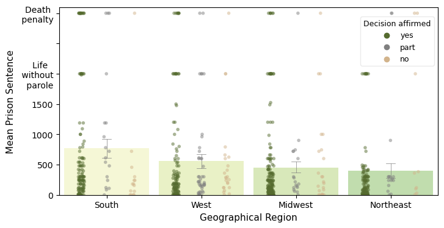

```python
### Plot the mean prison sentence per region

# Calculate mean value per category and sort cats by mean values
mean_values = dfCLAmain.groupby('region')['ImprisonmentLength'].mean()
sorted_cats = mean_values.sort_values(ascending=False).index

# Replace a tick label with a word to better explain coded years
special_labels = {2000: 'Life  \n without\n parole', 3000: 'Death \n penalty', 2500: ' ', 1500.0: '1500', 1000.0: '1000', 500.0: '500', 0.0: '0'}

# Colors for individual datapoints
custom_colors = ['darkolivegreen', 'grey', 'tan']

# Create a bar plot
plt.figure(figsize=(8, 4))
sns.barplot(x='region', y='ImprisonmentLength',
            data=dfCLAmain,
            errorbar=('ci', 95), errcolor='grey', errwidth=0.5, capsize=0.1,
            order=sorted_cats,
            palette = sns.color_palette('YlGn', 10),
            width=0.9,
            alpha=0.8,
            dodge=False)

# Add individual values as dots on top of the bars
sns.stripplot(x='region', y='ImprisonmentLength', hue='Affirmed',
              data = dfCLAmain, size=4, alpha=0.5, jitter=True, dodge=True,
              order=sorted_cats,
              palette = sns.set_palette(custom_colors))

# Customize labels
plt.xlabel('Geographical Region', fontsize=11)
plt.ylabel('Mean Prison Sentence', fontsize=11)
plt.xticks(fontsize=10)
plt.yticks(fontsize=10)
plt.xticks(rotation=0)

# Customize y-axis tick labels
tick_locations = plt.yticks()[0]
tick_labels = [special_labels.get(int(tick), str(tick)) for tick in tick_locations]
plt.yticks(tick_locations, tick_labels)
plt.ylim(bottom=0, top=3100)

# Legend params
plt.legend(title= 'Decision affirmed', title_fontsize=9, fontsize=9,
           framealpha=0.4, loc='upper right', bbox_to_anchor=(0.5, 0., 0.5, 0.97))

# Optionally save figure as PDF with transparent background perfect for inserting into executive summary
#plt.savefig('CLAbarRegionPrison.pdf', format='pdf', transparent=True)

# Display the plot
plt.show()
```

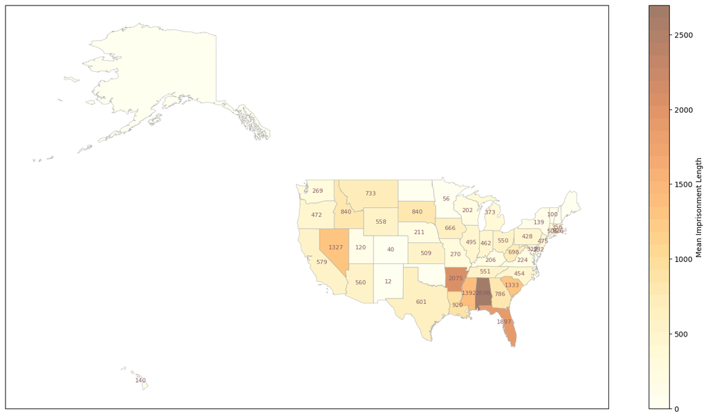

```python
### Plotting data on a U.S. map

## Colors
# Set the alpha value (transparency) for the entire colormap
alpha_value = 0.6
# Get the YlOrBr colormap with 5 colors and modify the alpha
my_color = cm.get_cmap('YlOrBr', 32)
my_color._init()
my_color._lut[:-3, -1] = alpha_value

# Load the shapefile
usa_map = gpd.read_file('/Users/miat./Documents/OtherWork/Jobs-Grants/Portfolio/Jupyter/CLA-ML/States_shapefile-shp/States_shapefile.shp')

# Calculate mean sentencing per jurisdiction
mean_sentencing_per_jurisdiction = dfCLAmain.groupby('Jurisdiction')['ImprisonmentLength'].mean()

# Merge
merged_data = usa_map.merge(mean_sentencing_per_jurisdiction, left_on='State_Code', right_index=True, how='left').fillna(0)

# Plot map
fig, ax = plt.subplots(figsize=(20, 10))

merged_data.plot(column='ImprisonmentLength', cmap = my_color, linewidth=0.5, ax=ax,
                 edgecolor='0.7', legend=True, legend_kwds={'label': "Mean Imprisonment Length", "orientation": "vertical"})


# Remove x / y coordinates
plt.xticks([])
plt.yticks([])

# Add annotations to the map for non-zero values
for x, y, label in zip(merged_data[merged_data['ImprisonmentLength'] > 0].geometry.centroid.x,
                       merged_data[merged_data['ImprisonmentLength'] > 0].geometry.centroid.y,
                       merged_data[merged_data['ImprisonmentLength'] > 0]['ImprisonmentLength']):
    ax.text(x, y, str(int(label)), fontsize=8, color = "#855A64", ha='center', va='center')

# Show the heatmap
plt.show()
```

# Multi-class classification

```python
### Features and Model

## Define features and target variable
feature_cols_cats_h1 = ['Disorder1',
                              'politics',
                              'GuiltyPlea',
                              'CriminalHistory'
                             ]
feature_cols_cont_h1 = ['OffenseTotalSeriousness']
# Merge predictors in case cats and cont
feature_cols_h1 = feature_cols_cats_h1 + feature_cols_cont_h1
# Define X and y
X_h1 = dfCLAmain[feature_cols_h1] # Features
y_h1 = dfCLAmain.SentenceType # Target variable

## Preprocessing categorical variables
preprocessor_h1 = ColumnTransformer(
    transformers=[
        ('cat', OneHotEncoder(), feature_cols_cats_h1)
    ],
    remainder='passthrough'
)

## Split dataset into training set and test set
X_train, X_test, y_train, y_test = train_test_split(X_h1,
                                                    y_h1,
                                                    test_size=0.3,
                                                    random_state=26)

## Building CART classifier pipeline
pipeline_h1 = Pipeline([
    ('preprocessor', preprocessor_h1),
    ('clf', DecisionTreeClassifier(criterion="gini",
                                   splitter="best",
                                   max_depth=4,
                                   min_samples_split=8,
                                   max_leaf_nodes=8
                                   ))
])

## Fitting the classifier
pipeline_h1.fit(X_train, y_train)

## Predict the response for test dataset
y_pred_h1 = pipeline_h1.predict(X_test)

# Model Accuracy, how often is the classifier correct?
print("Accuracy:",metrics.accuracy_score(y_test, y_pred_h1))


### Print model summary

# Predictions on the test set
y_pred_h1 = pipeline_h1.predict(X_test)

# Get unique categories from y_test and y_pred_h1
unique_categories_h1 = np.unique(np.concatenate((y_test, y_pred_h1), axis=None))

# Print classification report
print("Classification Report Model1:")
print(classification_report(y_test, y_pred_h1))

### Confusion matrix
# Print confusion matrix with labeled rows and columns
print("Confusion Matrix Model1:")
conf_matrix = confusion_matrix(y_test, y_pred_h1)
conf_df = pd.DataFrame(conf_matrix,
                       index=unique_categories_h1,
                       columns=unique_categories_h1)
print(conf_df)

# Calculate confusion matrix for excel
conf_matrix = confusion_matrix(y_test, y_pred_h1)
# Define labels for rows and columns
labels = np.unique(np.concatenate((y_test, y_pred_h1), axis=None))
conf_matrix_df = pd.DataFrame(conf_matrix, index=labels, columns=labels)
# Add additional labels for predicted classes
conf_matrix_df.columns = [f"Predicted_{label}" for label in conf_matrix_df.columns]
conf_matrix_df.index = [f"Actual_{label}" for label in conf_matrix_df.index]
```

```
Accuracy: 0.8591549295774648
Classification Report Model1:
                   precision    recall  f1-score   support

     Imprisonment       0.87      0.98      0.93       183
Institution/Treat       0.00      0.00      0.00         7
    ProbationOnly       0.50      0.13      0.21        23

         accuracy                           0.86       213
        macro avg       0.46      0.37      0.38       213
     weighted avg       0.80      0.86      0.82       213

Confusion Matrix Model1:
                   Imprisonment  Institution/Treat  ProbationOnly
Imprisonment                180                  0              3
Institution/Treat             7                  0              0
ProbationOnly                19                  1              3
```

## Performance (ROC)

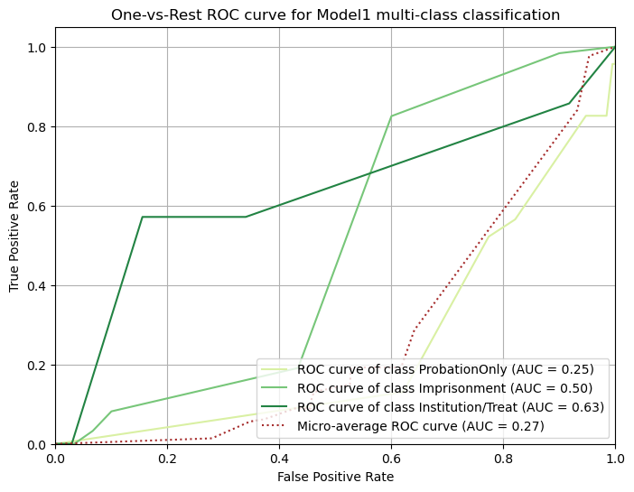

```python
### ROC

## ROC curve with One-vs-Rest multiclass ROC

# Define all classes present in the target variable
class_names_h1 = dfCLAmain['SentenceType'].unique()

# Binarize the target variable for each class separately
y_bin_h1 = label_binarize(y_test, classes=class_names_h1)

# Calculate the probabilities of each class
y_probs_h1 = pipeline_h1.predict_proba(X_test)

# Compute ROC curve and ROC area for each class
fpr = dict()
tpr = dict()
roc_auc_h1 = dict()
for i in range(len(class_names_h1)):
    fpr[i], tpr[i], _ = roc_curve(y_bin_h1[:, i], y_probs_h1[:, i])
    roc_auc_h1[i] = auc(fpr[i], tpr[i])

# Compute micro-average ROC curve and ROC area
fpr_micro, tpr_micro, _ = roc_curve(y_bin_h1.ravel(), y_probs_h1.ravel())
roc_auc_micro_h1 = auc(fpr_micro, tpr_micro)

# Plot ROC curves for each class
plt.figure(figsize=(8, 6))

# Define color palette
palette = sns.color_palette('YlGn', 3)

# Plot ROC curves for each class
for i, label in enumerate(class_names_h1):
    idx = list(class_names_h1).index(label)
    plt.plot(fpr[idx], tpr[idx], label='ROC curve of class {0} (AUC = {1:0.2f})'
             ''.format(label, roc_auc_h1[idx]), color=palette[idx])

# Plot micro-average ROC curve
plt.plot(fpr_micro, tpr_micro, label='Micro-average ROC curve (AUC = {0:0.2f})'
         ''.format(roc_auc_micro_h1), color='Brown', linestyle=':')

plt.xlim([0.0, 1.0])
plt.ylim([0.0, 1.05])
plt.xlabel('False Positive Rate')
plt.ylabel('True Positive Rate')
plt.title('One-vs-Rest ROC curve for Model1 multi-class classification')
plt.legend(loc="lower right")
plt.grid(True)

# Display the plot
plt.show()
```

## Tree

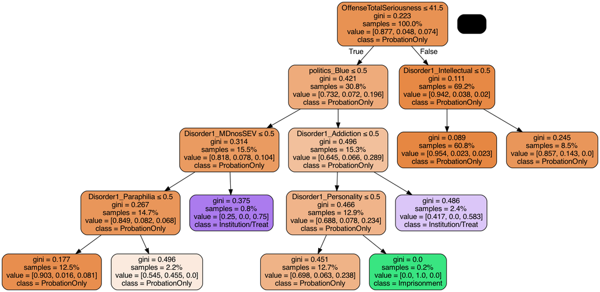

```python
#### Model 1 - Default params

### Visualization

## Visualize tree

# Get one-hot encoded feature names from preprocessor step
one_hot_encoder_h1 = pipeline_h1.named_steps['preprocessor'].named_transformers_['cat']
feature_names_encoded_h1 = one_hot_encoder_h1.get_feature_names_out(input_features=feature_cols_cats_h1)

# Combine encoded feature names with continuous feature names
feature_names_all_h1 = list(feature_names_encoded_h1) + feature_cols_cont_h1

# Define all classes present in the target variable
class_names_h1 = dfCLAmain['SentenceType'].unique()

# Plot
dot_data_h1 = StringIO()
export_graphviz(pipeline_h1.named_steps['clf'], out_file=dot_data_h1,
                filled=True, rounded=True, proportion= True,
                special_characters=True,
                feature_names=feature_names_all_h1,
                class_names=class_names_h1)
graph_h1 = pydotplus.graph_from_dot_data(dot_data_h1.getvalue())

# Modify graph attributes to set background color to transparent
graph_h1.set_graph_defaults(bgcolor='transparent')

# Display the plot
Image(graph_h1.create_png())
```

## Other classification method for cross-validation

```
Best parameters Model1: {'clf__max_depth': 5}
Best score Model1: 0.8772244897959183
```

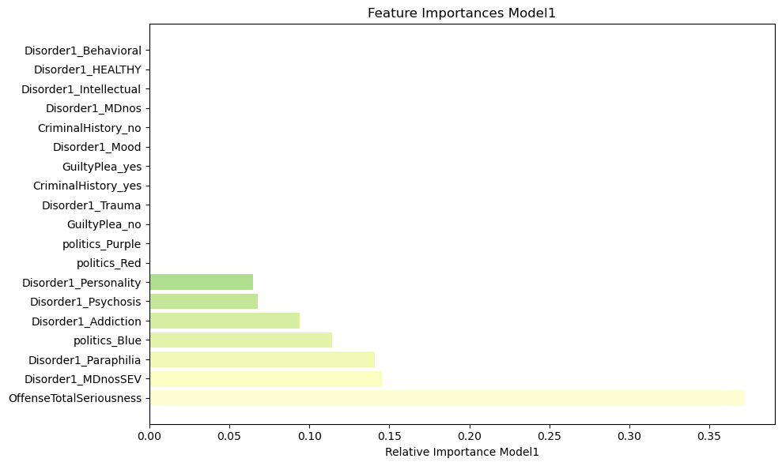

```python
### Cross validation

## Importances with cross-validation

# Defining grid of hyperparameters
param_grid_h1 = {
    'clf__max_depth': [3, 4, 5, 6, 7] # Define the range of values to search
}

# Grid search with cross-validation
grid_search_h1 = GridSearchCV(pipeline_h1,
                              param_grid_h1,
                              cv=10)

# Fitting the grid search
grid_search_h1.fit(X_train, y_train)

# Getting the best parameters and best score
best_params_h1 = grid_search_h1.best_params_
best_score_h1 = grid_search_h1.best_score_
print("Best parameters Model1:", best_params_h1)
print("Best score Model1:", best_score_h1)
## Using the best estimator to make predictions
best_clf_h1 = grid_search_h1.best_estimator_

# Feature Importance
importances_h1 = best_clf_h1.named_steps['clf'].feature_importances_

# Get feature names from preprocessor
ohe_categories_h1 = best_clf_h1.named_steps['preprocessor'].named_transformers_['cat'].categories_
encoded_feature_cols_cats_h1 = [f"{col}_{cat}" for i, col in enumerate(feature_cols_cats_h1) for cat in ohe_categories_h1[i]]
all_feature_names_h1 = encoded_feature_cols_cats_h1 + feature_cols_cont_h1

indices_h1 = np.argsort(importances_h1)[::-1]

plt.figure(figsize=(10, 6))
plt.title('Feature Importances Model1')
plt.barh(range(len(indices_h1)),
         importances_h1[indices_h1],
         color=sns.color_palette('YlGn', 18),
         align='center')
plt.yticks(range(len(indices_h1)), [all_feature_names_h1[i] for i in indices_h1])
plt.xlabel('Relative Importance Model1')
# Adjust margins
plt.tight_layout()
# Display the plot
plt.show()
```

## Next steps

What you could do next is try different parameters. For example, getting the best parameters and best score: best_params_h2 = grid_search_h2.best_params_ best_score_h2 = grid_search_h2.best_score_ print("Best parameters Model2:", best_params_h2) print("Best score Model2:", best_score_h2) Then, using the best estimator to make predictions: best_clf_h2 = grid_search_h2.best_estimator_ We can also try balancing weights (class_weight="balanced") As well as tweaking the tree depth ('clf__max_depth' : 3)

# Conclusions

Overall, we observe some interesting findings related to sentence lengths and types accross different jurisdictions. In this example of a machine learning analysis, we clearly see that we do not have enough cases to build a reliable multi-class classification model. We should either consolidate the classes into two, or consider a logistic regression that may yield more meaningful results.

Please note that this notebook contains only a small example from the analyses performed for this project. The purpose of this notebook is to demonstrate the thought process and types of analyses performed and is not exhaustive or complete. The full analyses performed for each project are reported in the published article.

Dr. Mia Thomaidou (2024)